# Introduction

# Running the simulation

Now, let us run the simulation. We also plot the evolution of infection curves (total and new).

Since later we will explore this with other graphs, it will be better if we wrap everything in a function.

```python
def Simulate(G,plot_all=False,plot_final=True):
    '''
    Runs the simulation outlined in the notebook, iterating epoch times.

    params:
    :G: a graph
    :plot_all: a boolean indicating whether or not to draw all steps in the evolution of G
    :plot_final: a boolean indicating wheter or not to draw the final result of the simulation.

    '''

    if plot_all:
        fig,ax=plt.subplots(int(epochs/5),5,figsize=(20,10))
        i,j=0,0

    t0=len(infected_history)-1
    for t in trange(epochs):
        new_infections.append(Update(G))
        infected_history.append(CountInfected(G))
        if plot_all:
            nx.draw_networkx(G,node_color=Color(G),ax=ax[i][j],node_size=20,with_labels=False,pos=pos)
            ax[i][j].set_title(f"t={t0}+{t}")
            j+=1
            if (j)%5==0:
                i+=1
                j=0

    infected_percentage=infected_history[-1]*100/(len(G.nodes()))
    if plot_final:
        k=3
    else:
        k=2
    fig,ax=plt.subplots(1,k,figsize=(15,5))
    ax[0].plot(infected_history)
    pd.Series(new_infections).plot(kind='bar',ax=ax[1],rot=45)
    if plot_final:
        nx.draw_networkx(G,node_color=Color(G),
                         node_size=50,
                         with_labels=False,
                         ax=ax[k-1]) #We do not fix the position here to get a more presentable graph.
        ax[k-1].set_title("% infected at the end: {0:.2f}%".format(infected_percentage))
    plt.show()
```

Running the simulation we can see how the pandemic progresses!

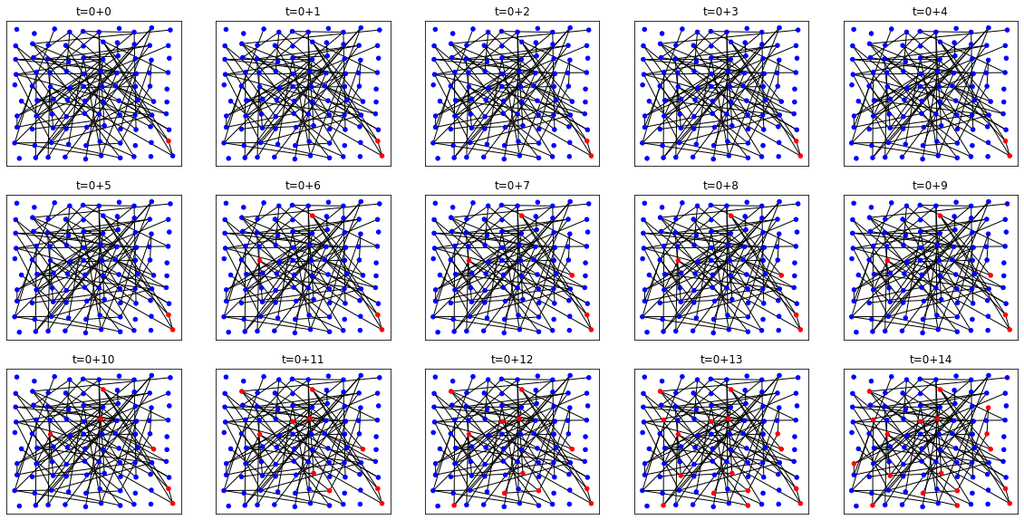

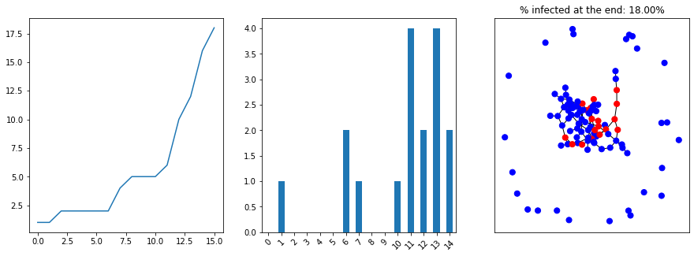

```python
Simulate(G,plot_all=True,plot_final=True)
```

We can keep updating everything by *epoch *timesteps.**

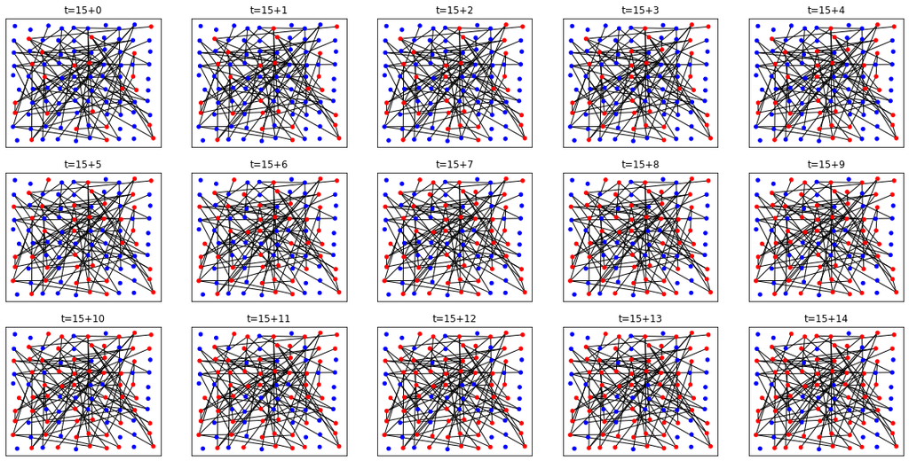

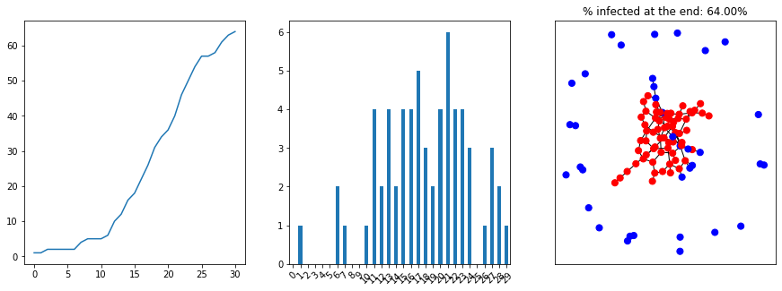

```python
Simulate(G,plot_all=True,plot_final=True)
```

# Other types of graphs

Now let us use some of NetworkX built-in 'community' graphs to see how things spread.

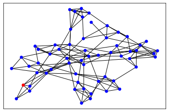

```python
G1=nx.relaxed_caveman_graph(10,6,0.3,seed=17)

Populate(G1)
infection_seed=np.random.randint(len(G1.nodes()))
G1.nodes[infection_seed]['I']='red'

nx.draw_networkx(G1,node_color=Color(G1),with_labels=False,node_size=30)
```

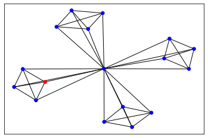

```python
G2=nx.windmill_graph(4, 5)

Populate(G2)
infection_seed=np.random.randint(len(G2.nodes()))
G2.nodes[infection_seed]['I']='red'

nx.draw_networkx(G2,node_color=Color(G2),with_labels=False,node_size=30)
```

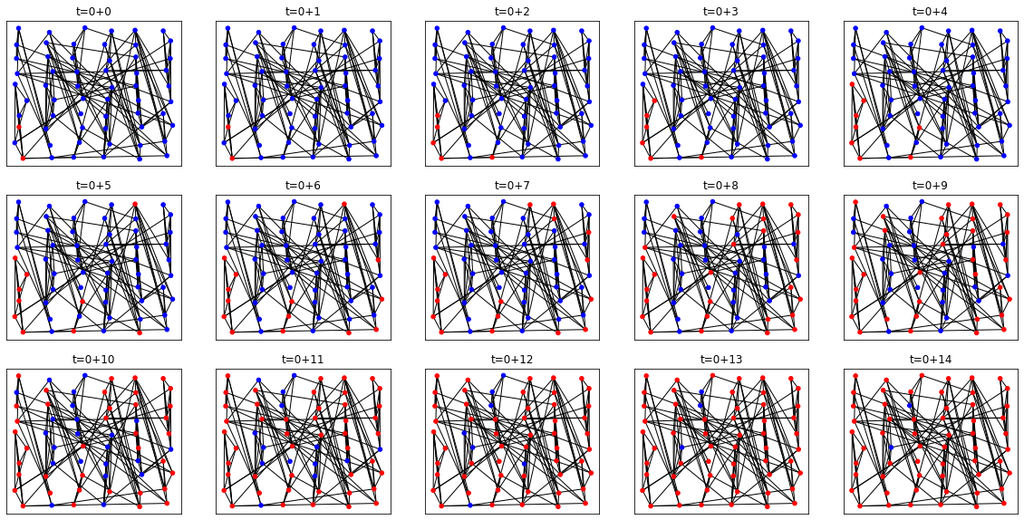

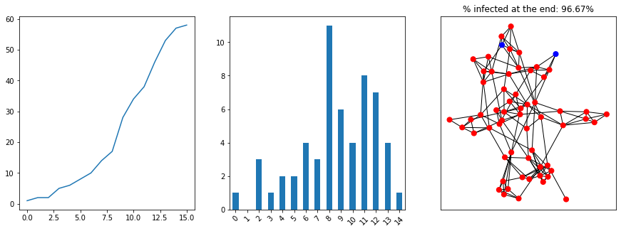

```python
new_infections=[]
infected_history=[1]

Simulate(G1,plot_all=True)
```

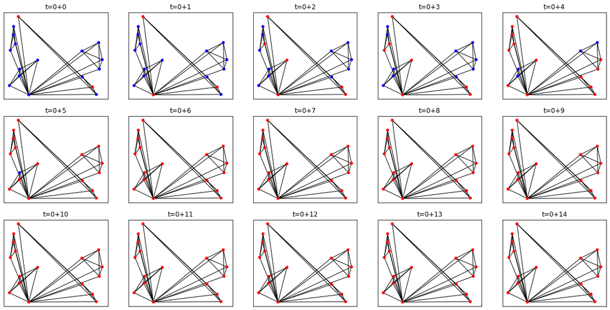

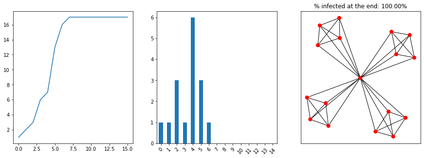

```python
new_infections=[]
infected_history=[1]

Simulate(G2,plot_all=True)
```

# Using a "real" graph

Finally, we simulate this in a real graph obtained using [Facebook data](https://snap.stanford.edu/data/ego-Facebook.html) (*J. McAuley and J. Leskovec. Learning to Discover Social Circles in Ego Networks. NIPS, 2012.*). We can think of this as something like 'how an idea spread' instead of a pandemic, where each node represents a social circle.

```python
data=pd.read_csv('./facebook_combined.txt',header=None,sep=' ')
edges=[]

for row in data.itertuples(index=False):
    edges.append((row[0],row[1]))

FbG=nx.Graph()
FbG.add_edges_from(edges)

Populate(FbG)
infection_seed=np.random.randint(len(FbG.nodes()))
FbG.nodes[infection_seed]['I']='red'
new_infections=[]
infected_history=[1]
```

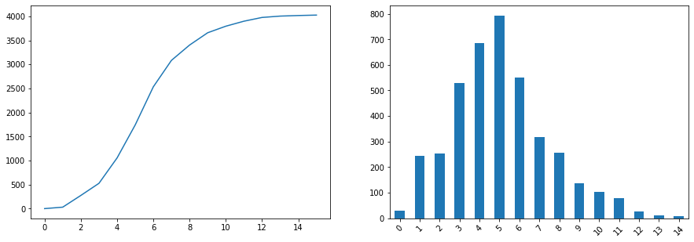

```python
Simulate(FbG,plot_all=False,plot_final=False)
```

To finish this notebook, we make an **extremely crude** simulation of social distancing by randomly deleting edges from the graph and comparing the numbers with the results above.

We use the same infection seed to have a valid comparison.

```python
#Saving the previous data

infected_history_no_dist=infected_history
new_infections_no_dist=new_infections
```

```python
#Each time we add an edge now we give it a 60% chance of being deleted.

edges=[]

for row in data.itertuples(index=False):
    edges.append((row[0],row[1]))
    if np.random.choice([True,False],p=[0.6,0.4]):
        del edges[-1]

FbG=nx.Graph()
FbG.add_edges_from(edges)

Populate(FbG)
FbG.nodes[infection_seed]['I']='red'
new_infections=[]
infected_history=[1]
```

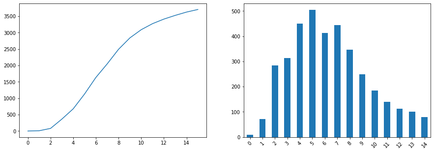

```python
Simulate(FbG,plot_all=False,plot_final=False)
```

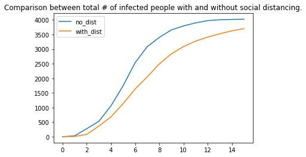

```python
plt.plot(infected_history_no_dist,label='no_dist')
plt.plot(infected_history,label='with_dist')
plt.legend()
plt.title('Comparison between total # of infected people with and without social distancing.')
plt.show()
```

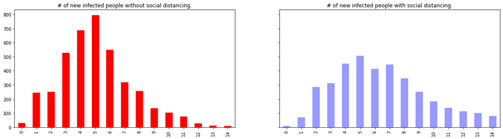

```python
fig,ax=plt.subplots(1,2,figsize=(20,5),sharey=True)
pd.Series(new_infections_no_dist).plot(kind='bar',label='no_dist',color='red',ax=ax[0])
ax[0].set_title('# of new infected people without social distancing.')
pd.Series(new_infections).plot(kind='bar',label='with_dist',color='blue',alpha=0.4,ax=ax[1])
ax[1].set_title('# of new infected people with social distancing.')

plt.show()
```

We can clearly see how social distancing 'flattens the curve'!